# Relatório 1

Alunos: André Gomes Regino (RA 230252) e Gustavo Caetano Borges (RA 262883)

## Variáveis de Entrada

```r
a1 <- read.csv(file = "a1.csv", header = FALSE, sep = ";", dec = ".")
a1 <- a1[,1]
b1 <- read.csv(file = "b1.csv", header = FALSE, sep = ";", dec = ".")
b1 <- b1[,1]
a1
```

```
##  [1]  1.2323944  7.7595693 14.1414943 11.0545966  2.7511814 13.9885594
##  [7]  8.0588607  6.7699532 13.6981390  9.4972725  9.5659775  4.7655213
## [13] 14.9342686  0.2779786  1.4296083
```

```r
b1
```

```
##  [1] 1.5275066 4.8267059 4.6537708 4.2065837 0.9076421 6.3311087 1.4736370
##  [8] 9.2429929 8.6426045 5.0446648 9.9381620 2.7493410 6.5248544 6.0254456
## [15] 2.5940320 8.9914781 0.1149999 6.0428365 7.4185673 4.0250625
```

```r
paired <- read.csv(file = "paired.csv", header = FALSE, sep = ",", dec = ".")
col1 <- paired[,1]
col2 <- paired[,2]
col1
```

```
##  [1] 12.9 13.5 12.8 15.6 17.2 19.2 12.6 15.3 14.4 11.3
```

```r
col2
```

```
##  [1] 13.1 12.2 11.2 13.3 15.2 15.8 12.2 13.4 12.9 11.7
```

## Exercício 1

Os arquivos a1.csv e b1.csv contém um conjunto de medidas cada um.

Use os seguintes testes

- teste t
- Wilcoxon rank sum

```r
t.test(a1,b1) #teste t
```

```
##
##  Welch Two Sample t-test
##
## data:  a1 and b1
## t = 2.0123, df = 20.915, p-value = 0.05724
## alternative hypothesis: true difference in means is not equal to 0
## 95 percent confidence interval:
##  -0.09871863  5.96056902
## sample estimates:
## mean of x mean of y
##  7.995025  5.064100
```

```r
wilcox.test(a1,b1) #wilcoxon rank sum
```

```
##
##  Wilcoxon rank sum test
##
## data:  a1 and b1
## W = 205, p-value = 0.06887
## alternative hypothesis: true location shift is not equal to 0
```

## Exercício 2

Gere um histograma dos dois dados e verifique se eles “se parecem” com Gaussianas. Tendo em vista esse resultado e o tamanho dos dados, quais dos dois valores de p-valor voce deve confiar. Eu não acho que há uma resposta correta para essa pergunta, mas eu gostaria de saber seus argumentos para a sua resposta

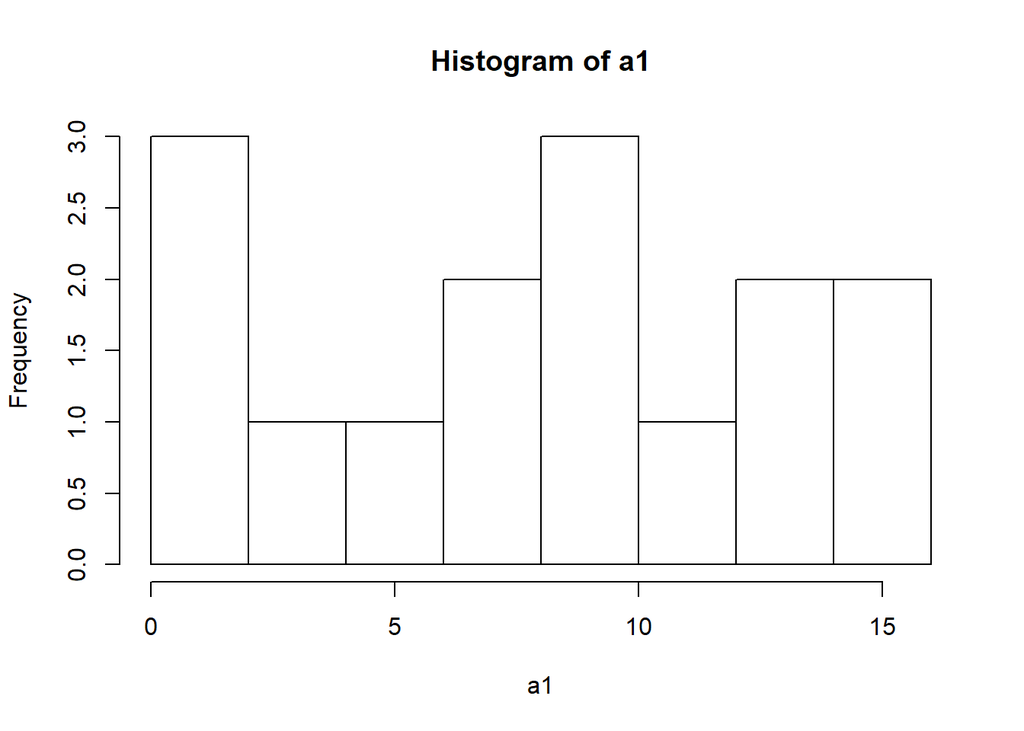

```r
hist(a1, breaks = 9)
```

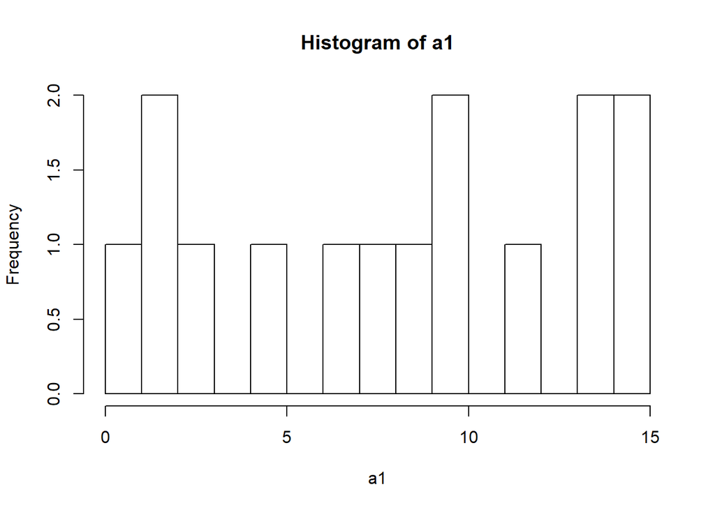

```r
hist(a1, breaks = 12)
```

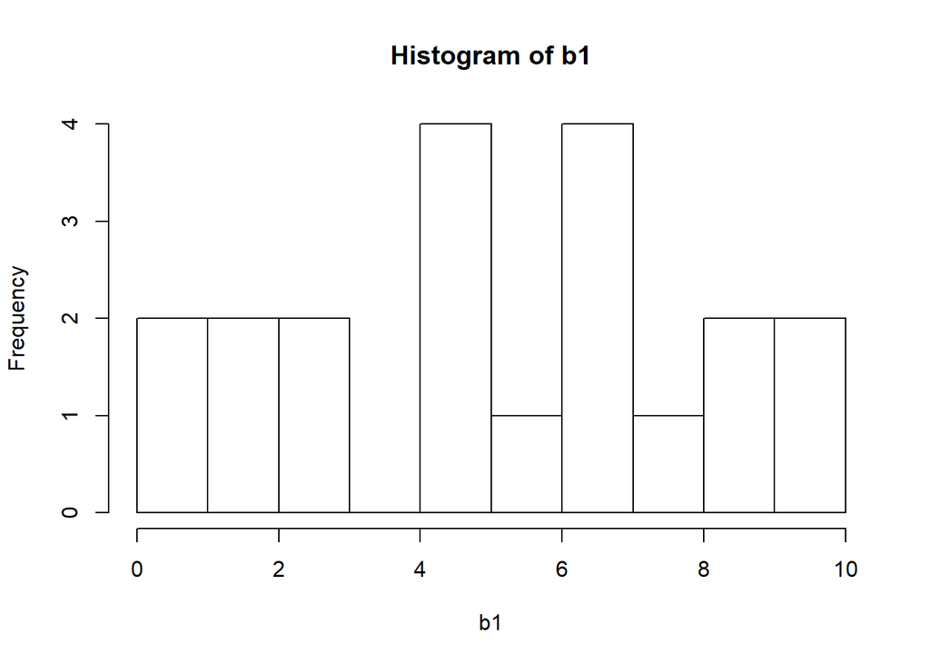

```r
hist(b1, breaks = 9)
hist(b1, breaks = 12)
```

[output not shown]

## Exercício 3

O arquivo paired.csv contem um conjunto de dados pareados, onde cada coluna é um grupo e as linhas o pareamento.

Rode os seguintes algoritmos

- teste t pareado
- Wilcoxon signed rank (a versão pareada do Wilcoxon sum rank).

Compare os dos p-valores. Discuta se voce tem uma opinião sobre quais dos dois usar. De novo eu não sei se há uma resposta certa para essa pergunta.

```r
t.test(col1, col2, paired = TRUE) #teste t pareado
```

```
##
##  Paired t-test
##
## data:  col1 and col2
## t = 3.7366, df = 9, p-value = 0.00465
## alternative hypothesis: true difference in means is not equal to 0
## 95 percent confidence interval:
##  0.5445317 2.2154683
## sample estimates:
## mean of the differences
##                    1.38
```

```r
wilcox.test(col1, col2, paired = TRUE) # wilcoxon pareado
```

```
##
##  Wilcoxon signed rank test
##
## data:  col1 and col2
## V = 52, p-value = 0.009766
## alternative hypothesis: true location shift is not equal to 0
```

## Exercício 4

Rode a versão não pareada do teste t e do Wilcoxon. A versão não pareada deve ser mais fraca (poder menor - maior p-valor) que as versões pareadas dos algoritmos. Verifique que isso é verdade.

```r
t.test(col1, col2, paired = FALSE)
```

```
##
##  Welch Two Sample t-test
##
## data:  col1 and col2
## t = 1.5582, df = 14.856, p-value = 0.1402
## alternative hypothesis: true difference in means is not equal to 0
## 95 percent confidence interval:
##  -0.5093412  3.2693412
## sample estimates:
## mean of x mean of y
##     14.48     13.10
```

```r
wilcox.test(col1, col2, paired = FALSE)
```

```
##
##  Wilcoxon rank sum test with continuity correction
##
## data:  col1 and col2
## W = 67.5, p-value = 0.1984
## alternative hypothesis: true location shift is not equal to 0
```

#### Resposta

Os p-valores das versões não pareadas (t = 0,1402 e wilcoxon = 0.1984) são, de fato, maiores do que os p-valores das versões pareadas (t = 0,00465 e wilcoxon = 0,00976).

## Exercício 5

Gere 2 conjuntos de 15 dados amostrados de uma normal de media 10 e 13, ambos com desvio padrão de 5.

Calcule a media do p-valor usando o teste t para 50 repetições dos pares descritos acima.

```r
mediap=0
for(i in 1:50){
    set1 = rnorm(15, 10, 5)
    set2 = rnorm(15, 13, 5)
    mediap[i] = t.test(set1,set2)[3]
}
mediap <- unlist(mediap)
mean(mediap)
```

```
## [1] 0.1809778
```

## Exercício 6

Calcule a media do p-valor para o teste t para 50 repetições dos pares acima, mas com 25 dados cada

```r
mediap1=0
for(i in 1:50){
    set1 = rnorm(25, 10, 5)
    set2 = rnorm(25, 13, 5)
    mediap1[i] = t.test(set1,set2)[3]
}
mediap1 <- unlist(mediap1)
mean(mediap1)
```

```
## [1] 0.1611066
```

## Exercício 7

Calcule a media do p-valor para o teste t para 50 repetições dos pares acima, com 15 dados cada mas com 10 como desvio padrão

```r
mediap2=0
for(i in 1:50){
    set1 = rnorm(15, 10, 10)
    set2 = rnorm(15, 13, 10)
    mediap2[i] = t.test(set1,set2)[3]
}
mediap2 <- unlist(mediap2)
mean(mediap2)
```

```
## [1] 0.3925769
```

## Exercício 8

Calcule a media do p-valor para o teste t para 50 repetições dos pares acima, com 15 dados, 5 de desvio padrão mas com medias 10 e 17.

```r
mediap3=0
for(i in 1:50){
    set1 = rnorm(15, 10, 5)
    set2 = rnorm(15, 17, 5)
    mediap3[i] = t.test(set1,set2)[3]
}
mediap3 <- unlist(mediap3)
mean(mediap3)
```

```
## [1] 0.01227457
```

## Exercício 9

Discuta a influencia dos 3 fatores no p-valor: numero de dados, ruído dos dados (o desvio padrão das fontes) e “tamanho da diferença” entre as fontes (diferença entre as médias)

#### Resposta

- **Número de dados:** Identificamos que quanto maior o número de dados (no exercício em questão), menor o p-valor. Exemplo: em uma das execuções, com 15 dados, obtivemos média de p-valores 0.1884612 e com 25 dados obtivemos média de p-valores 0.134518.
- **Rúido dos dados:** Identificamos que quanto maior o desvio padrão, maior o p-valor. Exemplo: em uma das execuções, com desvio padrão de 5, obtivemos média de p-valores 0.1884612 e com desvio padrão de 10 obtivemos média de p-valores 0.3657076.
- **Diferença entre fontes:** Identificamos que quanto maior a diferença entre as médias, menor o p-valor. Exemplo: em uma das execuções, com diferença entre as médias de 3 (10 e 13), obtivemos média de p-valores 0.1884612 e com diferenças de médias de 7 (10 e 17), obtivemos média de p-valores 0.003102274.